# Exploring the BRFSS data

## Setup

### Load packages

I am loading the `tidyverse` library, it contains ggplot2 as well as dplyr and some other useful libraries. You can find more information on it [here](http://tidyverse.org/).

```r
library( tidyverse )
```

### Load data

I am loading the data set but am also converting it to `tibble` format. The `tibble` format is a more up to date form of the `data.frame`.

```r
load( "brfss2013.RData" )
brfss2013 <- brfss2013 %>%
    as.tibble
```

## Part 1: Data

How was the data collected. Is it generalisable to a whole population?

The Behavioral Risk Factor Surveillance System (BRFSS) is a survey conducted in US territories on aged 18 and over adults that are not institutionalised. The aim is to investigate health related knowledge and actions taken by the person being surveyed, as well as links to health issues such as chronic diseases, physical injuries, and preventable infections.

In most US territories the survey is conducted annually with the others occurring at fixed time intervals. The calls are made to both landlines and cellular phones and are made 7 days a week in the daytime and the evening. For the landline calls an adult in the household is randomly selected, for cellular calls individuals are contacted and they indicate that they live in a private residence or college housing.

A computer system randomly selects telephone numbers. For most US territories a disproportionate stratified sampling method is used, but some use a simple random sampling design. We also have to be careful about various forms of bias. Beacuse of how the survey is conducted it would be very easy for individuals to choose not to respond or for the callers to not be available at the time they are called.

There is a potential overlap in participants where people have a landline and a cellular phone. Once it was realised that a significant proportion of households didn’t have a landline the sampling design was adapted to account for cellular numbers and a weighting applied to counter the overlap in participants.

The data is prospective observational data, where data is collected throughout the study and treatments aren’t prescribed to the experimental units. This also means that any results can’t prove causal links between variables. The random sampling of the participants means that conclusions can be generalised to the whole population.

## Part 2: Research questions

**Research quesion 1:**

Sleep is a factor that I believe is often not thought about when looking at overall health, but I think it potentially can be the biggest factor. Someone who is very tired is more likely to notice if they aren’t feeling quite right.

It would also be good to look at if there is a stronger correlation between lack of sleep and poor physical or poor mental health, so this will be my question.

**Research quesion 2:**

As there are many differences between states it would be interesting to see if there is a correlation between the state lived in and the quality of sleep for the participant. If I find that there is a correlation between the two it would then be good to identify if there are specific differences between states that accounts for this.

So, is there an indication that state and sleep quality are correlated, is my question.

**Research quesion 3:**

When you are younger individuals who exercise a lot tend to also eat and drink huge amounts of unhealthy food, because the exercise balances it out so they can. It would be interesting to see if this behaviour carries on into adults or if the reduced metabolism means that people who exercise a lot are also healthy in what they eat.

So my question is, an investigation for a correlation between unhealthy eating or drinking habits and exercising.

## Part 3: Exploratory data analysis

**Research quesion 1:**

Have a look at the variables relevant to the question.

```r
brfss2013 %>%
    select( physhlth, menthlth, sleptim1 )
```

```
## # A tibble: 491,775 x 3
##    physhlth menthlth sleptim1
##       <int>    <int>    <int>
##  1       30       29       NA
##  2        0        0        6
##  3        3        2        9
##  4        2        0        8
##  5       10        2        6
##  6        0        0        8
##  7        1       15        7
##  8        5        0        6
##  9        0        0        8
## 10        0        0        8
## # ... with 491,765 more rows
```

Having looked at the values in columns `physhlth`, `menthlth`, and `sleptim1` I see that there are some values that are invalid for my purposes, such as values greater than 30 in `physhlth`, or null. These are not relevant to my question so I will filter the data set to remove these.

```r
brfss2013 %>%
    select( physhlth ) %>%
    unique %>%
    .[[1]]
```

```
##  [1] 30  0  3  2 10  1  5 NA 14  4 23 15 25 20 28  7  8 26 22 12 11 21 17
## [24]  6  9 29 13 16 19 18 27 24 60
```

```r
brfss2013 %>%
    select( menthlth ) %>%
    unique %>%
    .[[1]]
```

```
##  [1]   29    0    2   15    1   30    3   NA    5    8    7   10   25    4
## [15]   20   21    6   14   26   18   12   16   28    9   13   17   27   24
## [29]   23   11   22   19 5000  247
```

```r
brfss2013 %>%
    select( sleptim1 ) %>%
    unique %>%
    .[[1]]
```

```
##  [1]  NA   6   9   8   7   3   5  10   4   2  12  16  11  13  14  19  18
## [18]  15   1  20  17  24  23  21  22 103 450   0
```

```r
q1_data <- brfss2013 %>%
    select( physhlth, menthlth, sleptim1 ) %>%
    filter( !is.na( physhlth ), !is.na( menthlth ), !is.na( sleptim1 ), physhlth < 31, menthlth < 31, sleptim1 < 25 )
```

Historgrams will give a reasonable view of the distribution of values.

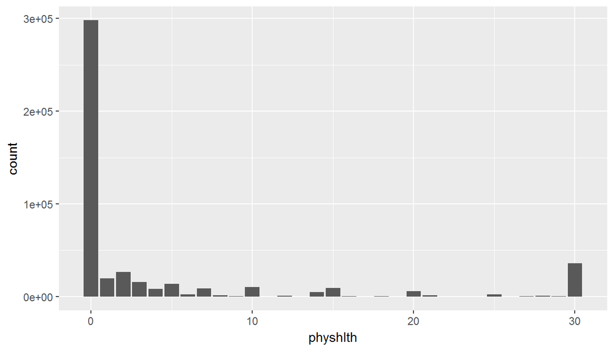

```r
ggplot( data = q1_data ) +
    geom_histogram( aes( x = physhlth ), stat = "count" )
```

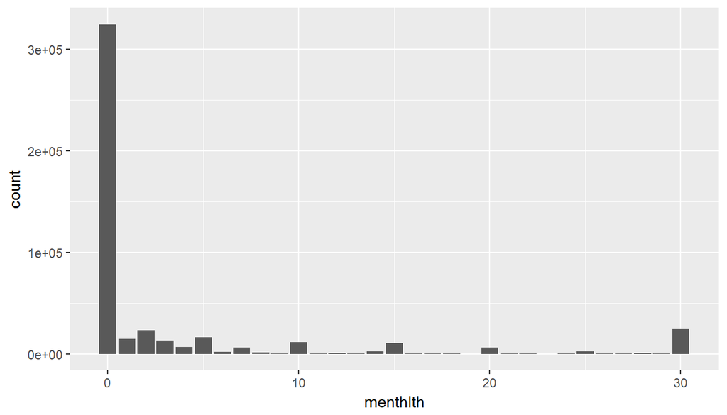

```r
ggplot( data = q1_data ) +
    geom_histogram( aes( x = menthlth ), stat = "count" )
```

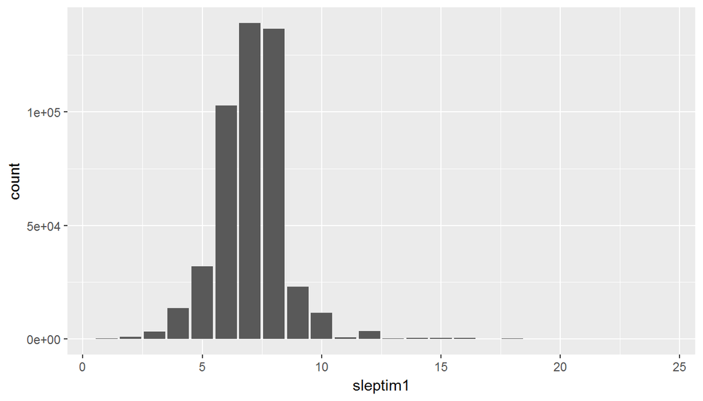

```r
ggplot( data = q1_data ) +
    geom_histogram( aes( x = sleptim1 ), stat = "count" )
```

The histograms of `phyhlth` and `menthlth` are incredibly similar in overall shape. There are more people reporting that they have bad physical health days than bad mental health days.

Looking at some basic statistics can give us more of a feel for the distributions.

```r
q1_data %>%
    summarise( min = min( physhlth ), max = max( physhlth ), mean = mean( physhlth ), meidan = median( physhlth ), sd = sd( physhlth ) )
```

```
## # A tibble: 1 x 5
##     min   max     mean meidan       sd
##   <dbl> <dbl>    <dbl>  <dbl>    <dbl>
## 1     0    30 4.247223      0 8.731567
```

```r
q1_data %>%
    summarise( min = min( menthlth ), max = max( menthlth ), mean = mean( menthlth ), median = median( menthlth ), sd = sd( menthlth ) )
```

```
## # A tibble: 1 x 5
##     min   max     mean median       sd
##   <dbl> <dbl>    <dbl>  <dbl>    <dbl>
## 1     0    30 3.327367      0 7.627472
```

```r
q1_data %>%
    summarise( min = min( sleptim1 ), max = max( sleptim1 ), mean = mean( sleptim1 ), median = median( sleptim1 ), sd = sd( sleptim1 ) )
```

```
## # A tibble: 1 x 5
##     min   max     mean median       sd
##   <dbl> <dbl>    <dbl>  <dbl>    <dbl>
## 1     1    24 7.051288      7 1.451933
```

I think there are a lot of unique values in each vairable, so I am going to categorise them reasonably.

The number of hours slept can be easily split into 3 categories, ‘enough’, ‘too little’, ‘too much’.

```r
q1_data <- q1_data %>%
    mutate(
        cat_sleptim1 = ifelse( sleptim1 <= 5, 'too little', ifelse( sleptim1 >= 11, 'too much', 'enough' ) )
    )
```

The number of days that pyhsical or mental health is not good we can categorise as ‘none’, ‘1-19’, ‘20-30’.

```r
q1_data <- q1_data %>%
    mutate(
        cat_physhlth = ifelse( physhlth == 0, 'none', ifelse( physhlth >= 20, '20-30', '1-19' ) ),
        cat_menthlth = ifelse( menthlth == 0, 'none', ifelse( menthlth >= 20, '20-30', '1-19' ) )
    )
```

We can then look at the proportions of each value in each variable.

```r
q1_data %>%
    group_by( cat_sleptim1 ) %>%
    summarise( count = n() ) %>%
    mutate(
        pct = round( count * 100 / sum( count ), 2 )
    )
```

```
## # A tibble: 3 x 3
##   cat_sleptim1  count   pct
##          <chr>  <int> <dbl>
## 1       enough 412958 88.10
## 2   too little  49970 10.66
## 3     too much   5794  1.24
```

```r
q1_data %>%
    group_by( cat_physhlth ) %>%
    summarise( count = n() ) %>%
    mutate(
        pct = round( count * 100 / sum( count ), 2 )
    )
```

```
## # A tibble: 3 x 3
##   cat_physhlth  count   pct
##          <chr>  <int> <dbl>
## 1         1-19 123106 26.26
## 2        20-30  47645 10.16
## 3         none 297971 63.57
```

```r
q1_data %>%
    group_by( cat_menthlth ) %>%
    summarise( count = n() ) %>%
    mutate(
        pct = round( count * 100 / sum( count ), 2 )
    )
```

```
## # A tibble: 3 x 3
##   cat_menthlth  count   pct
##          <chr>  <int> <dbl>
## 1         1-19 109493 23.36
## 2        20-30  34733  7.41
## 3         none 324496 69.23
```

And look at the stats by these new categories.

```r
q1_data %>%
    group_by( cat_sleptim1 ) %>%
    summarise( min = min( physhlth ), max = max( physhlth ), mean = mean( physhlth ), median = median( physhlth ), sd = sd( physhlth ) )
```

```
## # A tibble: 3 x 6
##   cat_sleptim1   min   max      mean median        sd
##          <chr> <dbl> <dbl>     <dbl>  <dbl>     <dbl>
## 1       enough     0    30  3.633101      0  8.041659
## 2   too little     0    30  8.595417      2 11.661577
## 3     too much     0    30 10.517087      3 12.509267
```

```r
q1_data %>%
    group_by( cat_sleptim1 ) %>%
    summarise( min = min( menthlth ), max = max( menthlth ), mean = mean( menthlth ), median = median( menthlth ), sd = sd( menthlth ) )
```

```
## # A tibble: 3 x 6
##   cat_sleptim1   min   max     mean median        sd
##          <chr> <dbl> <dbl>    <dbl>  <dbl>     <dbl>
## 1       enough     0    30 2.730350      0  6.796166
## 2   too little     0    30 7.779188      0 11.160642
## 3     too much     0    30 7.484294      0 11.256416
```

**Research quesion 2:**

When trying to look at the columns `_state` and `sleptim1`, column names from the data codebook, an error occured indicating that the column `_state` doesn’t exist. So we look for any columns containing the string ’_state’ which will probably be the correct one.

```r
brfss2013 %>%
    names %>%
    grep( "_state", ., value = TRUE )
```

```
## [1] "X_state"
```

Means the column is actually `X_state`

```r
brfss2013 %>%
    select( X_state, sleptim1 )
```

```
## # A tibble: 491,775 x 2
##    X_state sleptim1
##     <fctr>    <int>
##  1 Alabama       NA
##  2 Alabama        6
##  3 Alabama        9
##  4 Alabama        8
##  5 Alabama        6
##  6 Alabama        8
##  7 Alabama        7
##  8 Alabama        6
##  9 Alabama        8
## 10 Alabama        8
## # ... with 491,765 more rows
```

Having a look at the values in the columns there are some that are not relevant for my investigation, so I will filter these out along with any null values.

```r
brfss2013 %>%
    select( X_state ) %>%
    unique %>%
    .[[1]] %>%
    sort
```

```
##  [1] 0                    Alabama              Alaska
##  [4] Arizona              Arkansas             California
##  [7] Colorado             Connecticut          Delaware
## [10] District of Columbia Florida              Georgia
## [13] Hawaii               Idaho                Illinois
## [16] Indiana              Iowa                 Kansas
## [19] Kentucky             Louisiana            Maine
## [22] Maryland             Massachusetts        Michigan
## [25] Minnesota            Mississippi          Missouri
## [28] Montana              Nebraska             Nevada
## [31] New Hampshire        New Jersey           New Mexico
## [34] New York             North Carolina       North Dakota
## [37] Ohio                 Oklahoma             Oregon
## [40] Pennsylvania         Rhode Island         South Carolina
## [43] South Dakota         Tennessee            Texas
## [46] Utah                 Vermont              Virginia
## [49] Washington           West Virginia        Wisconsin
## [52] Wyoming              Guam                 Puerto Rico
## [55] 80
## 55 Levels: 0 Alabama Alaska Arizona Arkansas California ... 80
```

```r
brfss2013 %>%
    select( sleptim1 ) %>%
    unique %>%
    .[[1]]
```

```
##  [1]  NA   6   9   8   7   3   5  10   4   2  12  16  11  13  14  19  18
## [18]  15   1  20  17  24  23  21  22 103 450   0
```

```r
q2_data <- brfss2013 %>%
    select( X_state, sleptim1 ) %>%
    filter( X_state != "80", X_state != "0", !is.na( sleptim1 ), sleptim1 < 25 )
```

By looking at histograms of counts we can get a good visual view of the distributions of the variables.

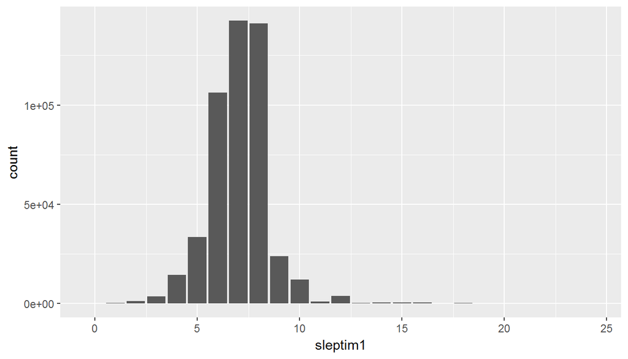

```r
ggplot( data = q2_data ) +
    geom_histogram( aes( x = sleptim1 ), stat = "count" )
```

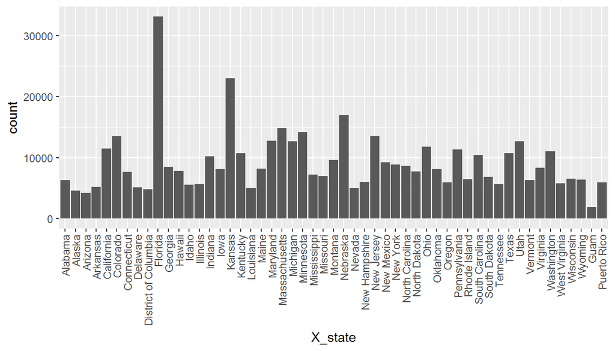

```r
ggplot( data = q2_data ) +
    geom_histogram( aes( x = X_state ), stat = 'count' ) +
    theme( axis.text.x = element_text( angle = 90, hjust = 1, vjust = 0.5 ) )
```

We will use the same categorisation of the amount of sleep the respondant is getting.

```r
q2_data <- q2_data %>%
    mutate(
        cat_sleptim1 = ifelse( sleptim1 <= 5, 'too little', ifelse( sleptim1 >= 11, 'too much', 'enough' ) )
    )
```

And then we can look at the counts of the variables.

```r
q2_summary_tbl <- q2_data %>%
    group_by( X_state, cat_sleptim1 ) %>%
    summarise( count = n() ) %>%
    mutate(
        pct = round( count * 100 / sum( count ), 2 )
    )

q2_summary_tbl
```

```
## # A tibble: 159 x 4
## # Groups:   X_state [53]
##     X_state cat_sleptim1 count   pct
##      <fctr>        <chr> <int> <dbl>
##  1  Alabama       enough  5336 84.43
##  2  Alabama   too little   850 13.45
##  3  Alabama     too much   134  2.12
##  4   Alaska       enough  4039 88.87
##  5   Alaska   too little   449  9.88
##  6   Alaska     too much    57  1.25
##  7  Arizona       enough  3726 88.82
##  8  Arizona   too little   433 10.32
##  9  Arizona     too much    36  0.86
## 10 Arkansas       enough  4498 87.07
## # ... with 149 more rows
```

We can then look for states where the proportion of people getting ‘enough’, ‘too little’, or ‘too much’ sleep is particularly high. Will also print out the min and max percentage to give context.

```r
q2_summary_tbl %>%
    filter( cat_sleptim1 == "enough" ) %>%
    .['pct'] %>%
    min
```

```
## [1] 81.37
```

```r
q2_summary_tbl %>%
    filter( cat_sleptim1 == "enough" ) %>%
    .['pct'] %>%
    max
```

```
## [1] 91.89
```

```r
q2_summary_tbl %>%
    filter( cat_sleptim1 == "enough", pct > 90.5 )
```

```
## # A tibble: 8 x 4
## # Groups:   X_state [8]
##        X_state cat_sleptim1 count   pct
##         <fctr>        <chr> <int> <dbl>
## 1     Colorado       enough 12366 91.89
## 2         Iowa       enough  7322 90.67
## 3       Kansas       enough 20844 90.65
## 4    Minnesota       enough 12962 91.44
## 5     Nebraska       enough 15410 90.80
## 6 North Dakota       enough  7022 90.99
## 7 South Dakota       enough  6224 90.99
## 8      Wyoming       enough  5761 90.58
```

```r
q2_summary_tbl %>%
    filter( cat_sleptim1 == "too little" ) %>%
    .['pct'] %>%
    min
```

```
## [1] 7.36
```

```r
q2_summary_tbl %>%
    filter( cat_sleptim1 == "too little" ) %>%
    .['pct'] %>%
    max
```

```
## [1] 17.08
```

```r
q2_summary_tbl %>%
    filter( cat_sleptim1 == "too little", pct > 13.5 )
```

```
## # A tibble: 4 x 4
## # Groups:   X_state [4]
##         X_state cat_sleptim1 count   pct
##          <fctr>        <chr> <int> <dbl>
## 1      Kentucky   too little  1612 15.06
## 2 West Virginia   too little   890 15.32
## 3          Guam   too little   321 17.08
## 4   Puerto Rico   too little   998 16.91
```

```r
q2_summary_tbl %>%
    filter( cat_sleptim1 == "too much" ) %>%
    .['pct'] %>%
    min
```

```
## [1] 0.75
```

```r
q2_summary_tbl %>%
    filter( cat_sleptim1 == "too much" ) %>%
    .['pct'] %>%
    max
```

```
## [1] 2.66
```

```r
q2_summary_tbl %>%
    filter( cat_sleptim1 == "too much", pct > 1.75 )
```

```
## # A tibble: 7 x 4
## # Groups:   X_state [7]
##                X_state cat_sleptim1 count   pct
##                 <fctr>        <chr> <int> <dbl>
## 1              Alabama     too much   134  2.12
## 2             Arkansas     too much   103  1.99
## 3 District of Columbia     too much    95  1.97
## 4            Louisiana     too much    96  1.90
## 5          Mississippi     too much   191  2.66
## 6             Missouri     too much   124  1.79
## 7       South Carolina     too much   196  1.88
```

I don’t know enough about US territories to try to pick out differences in them that could cause these differences in sleep category proportions but I can see that there are some big differences in the proportions. These suggest that some US territories do have more people getting a certain category of sleep than other US territories, for example, Colorado has the highest proportion of respondants getting ‘enough’ sleep.

**Research quesion 3:**

Have a quick look at the variables for this question.

```r
brfss2013 %>%
    select( exerany2, fruit1, genhlth, alcday5 )
```

```
## # A tibble: 491,775 x 4
##    exerany2 fruit1   genhlth alcday5
##      <fctr>  <int>    <fctr>   <int>
##  1       No    104      Fair     201
##  2      Yes    301      Good       0
##  3       No    203      Good     220
##  4      Yes    306 Very good     208
##  5       No    302      Good     210
##  6      Yes    206 Very good       0
##  7      Yes    325      Fair     201
##  8      Yes    320      Good     202
##  9      Yes    101 Excellent     101
## 10      Yes    202      Good       0
## # ... with 491,765 more rows
```

Check out the unique values from each variable to check if they are valid.

```r
brfss2013 %>%
    select( exerany2 ) %>%
    unique %>%
    .[[1]]
```

```
## [1] No   Yes  <NA>
## Levels: Yes No
```

```r
brfss2013 %>%
    select( fruit1 ) %>%
    unique %>%
    .[[1]] %>%
    sort
```

```
##   [1]   0   1   2 101 102 103 104 105 106 107 108 109 110 112 114 115 116
##  [18] 117 120 121 125 130 137 150 160 180 199 201 202 203 204 205 206 207
##  [35] 208 209 210 211 212 213 214 215 216 217 218 219 220 221 222 223 224
##  [52] 225 226 227 228 229 230 231 232 233 234 235 236 240 250 260 269 280
##  [69] 300 301 302 303 304 305 306 307 308 309 310 311 312 313 314 315 316
##  [86] 317 318 319 320 321 322 323 324 325 326 327 328 329 330 331 332 333
## [103] 334 335 336 337 338 339 340 342 343 344 345 346 347 348 350 352 353
## [120] 355 356 359 360 361 362 365 366 368 370 373 374 375 376 377 380 381
## [137] 384 385 387 388 390 393 398 399
```

```r
brfss2013 %>%
    select( genhlth ) %>%
    unique %>%
    .[[1]]
```

```
## [1] Fair      Good      Very good Excellent Poor      <NA>
## Levels: Excellent Very good Good Fair Poor
```

```r
brfss2013 %>%
    select( alcday5 ) %>%
    unique %>%
    .[[1]] %>%
    sort
```

```
##  [1]   0   1   2 101 102 103 104 105 106 107 201 202 203 204 205 206 207
## [18] 208 209 210 211 212 213 214 215 216 217 218 219 220 221 222 223 224
## [35] 225 226 227 228 229 230
```

Based of the values in the codebook that we are expecting in this column, filter out the nulls and invalid values for our question data set.

```r
q3_data <- brfss2013 %>%
    select( exerany2, fruit1, genhlth, alcday5 ) %>%
    filter( !is.na( exerany2 ), !is.na( fruit1 ), !is.na( genhlth ), !is.na( alcday5 ), alcday5 == 0 | alcday5 > 99 | alcday5 < 300, fruit1 < 400, fruit1 > 100 | fruit1 == 0 )
```

Categorise the variables.

```r
q3_data <- q3_data %>%
    mutate(
        cat_fruit1 = ifelse( fruit1 == 0 | fruit1 == 300, "rarely", ifelse( fruit1 < 200, "daily", ifelse( fruit1 < 300, "weekly", "monthly" ) ) ),
        cat_alcday5 = ifelse( alcday5 > 100 & alcday5 < 200, ( alcday5 - 100 ) * 4, ifelse( alcday5 > 200 & alcday5 < 300, alcday5 - 200, alcday5 ) ),
        cat_alcday5 = ifelse( cat_alcday5 == 0, "never", ifelse( cat_alcday5 < 11, "1-10", "11-30" ) )
    )
```

Have a quick look at the counts of combinations of the variables.

```r
q3_data %>%
    group_by( exerany2 ) %>%
    summarise( count = n() ) %>%
    mutate(
        pct = count * 100 / sum( count )
    ) %>%
    arrange( -count )
```

```
## # A tibble: 2 x 3
##   exerany2  count      pct
##     <fctr>  <int>    <dbl>
## 1      Yes 325181 72.91626
## 2       No 120784 27.08374
```

```r
q3_data %>%
    group_by( exerany2, cat_fruit1 ) %>%
    summarise( count = n() ) %>%
    mutate(
        pct = round( count * 100 / sum( count ), 2 )
    )
```

```
## # A tibble: 8 x 4
## # Groups:   exerany2 [2]
##   exerany2 cat_fruit1  count   pct
##     <fctr>      <chr>  <int> <dbl>
## 1      Yes      daily 161997 49.82
## 2      Yes    monthly  83338 25.63
## 3      Yes     rarely   9020  2.77
## 4      Yes     weekly  70826 21.78
## 5       No      daily  43900 36.35
## 6       No    monthly  37641 31.16
## 7       No     rarely   9242  7.65
## 8       No     weekly  30001 24.84
```

```r
q3_data %>%
    group_by( exerany2, genhlth ) %>%
    summarise( count = n() ) %>%
    mutate(
        pct = round( count * 100 / sum( count ), 2 )
    )
```

```
## # A tibble: 10 x 4
## # Groups:   exerany2 [2]
##    exerany2   genhlth  count   pct
##      <fctr>    <fctr>  <int> <dbl>
##  1      Yes Excellent  66784 20.54
##  2      Yes Very good 118767 36.52
##  3      Yes      Good  94997 29.21
##  4      Yes      Fair  33992 10.45
##  5      Yes      Poor  10641  3.27
##  6       No Excellent  11099  9.19
##  7       No Very good  28135 23.29
##  8       No      Good  41192 34.10
##  9       No      Fair  26029 21.55
## 10       No      Poor  14329 11.86
```

```r
q3_data %>%
    group_by( exerany2, cat_alcday5 ) %>%
    summarise( count = n() ) %>%
    mutate(
        pct = round( count * 100 / sum( count ), 2 )
    )
```

```
## # A tibble: 6 x 4
## # Groups:   exerany2 [2]
##   exerany2 cat_alcday5  count   pct
##     <fctr>       <chr>  <int> <dbl>
## 1      Yes        1-10 123538 37.99
## 2      Yes       11-30  54583 16.79
## 3      Yes       never 147060 45.22
## 4       No        1-10  32709 27.08
## 5       No       11-30  12668 10.49
## 6       No       never  75407 62.43
```

From the summaries of `exreany2`, the ‘Yes’ or ‘No’ indicator of if the respondant exercises, against each other variable we can see that people who exercise seem to drink more alcohol and have a more positive self assessment of their overall health.